# Analyzing Ford GoBike Program Data

## Investigation Overview

In this investigation, I wanted to look at the data of Ford GoBike, which could be used to predict the number of trips and the duration of all trips, and the characteristics which affect that. so we can answer this question to analyze data:

1. what is relation between duration and other characteristics
2. When are most trips taken in terms of time of day, day of the week?
3. How long does the average trip take?
4. Does the above depend on if a user is a subscriber or customer?
5. Does the above depend on if a user is a Male or Female?

## Dataset Overview

The dataset(s) provided to us by Ford contain the following fields:

- Trip Duration (in seconds)
- Start Time and Date
- End Time and Date
- Start Station ID
- Start Station Name
- Start Station Latitude
- Start Station Longitude
- End Station ID
- End Station Name
- End Station Latitude
- End Station Longitude
- Bike ID
- User Type
- Member Year of Birth
- Member Gender

## Males Vs. Female

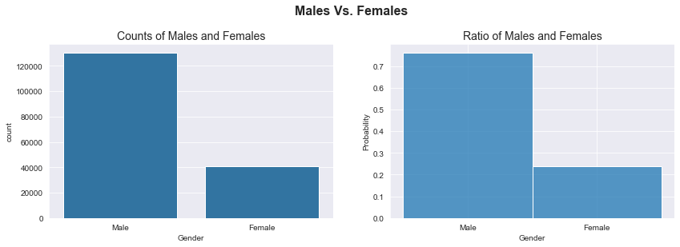

## Customers Vs. Subscribers

User Type is an important characteristics in our data and other data depend on it so we must to know the numbers and percentage of customers and subscribers, In the below figures we can see that subscribers is much more than customers it represent 89.2 percent of users, whereas customers represents 10.8 percent.

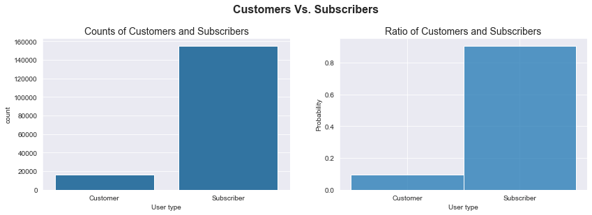

## The distribution of the duration for trips.

The most trips duration is smaller than 20 minutes and the peak(the most time takes) around (4 - 10) min. The average trip duration is 8.4 min .

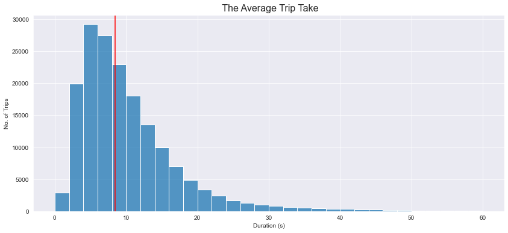

## The distribution of the ages.

The most common users ages who had a ride between (25 - 40) years No users less than 20 years old Low users between (45 - 80) years

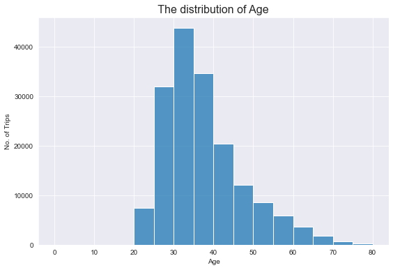

## The relation between duration of ride bikes and Gender

In spite of number of males more than females but females had a longer rides than males. average rides for male takes 500 sec. average rides for female takes 600 sec.

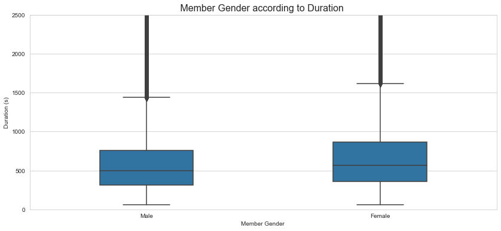

## The relation between duration of ride bikes and user type

Here we can see that higher percentage of customers are taking longer trips then compared to subscribers. average rides for customer takes 750 sec. average rides for subscriber takes 500 sec.

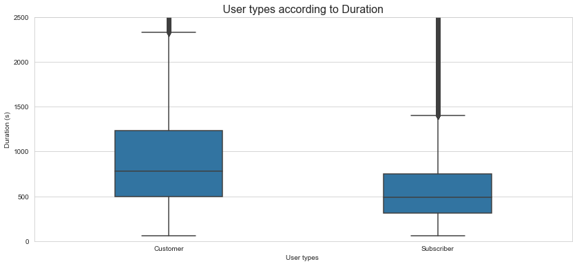

## The relation between Age of users and the duration of trips.

- Ages between [20:40] have a longer durations (trips) so when user was younger they have a long trips.
- when the user is older the duration of the trip decrease.

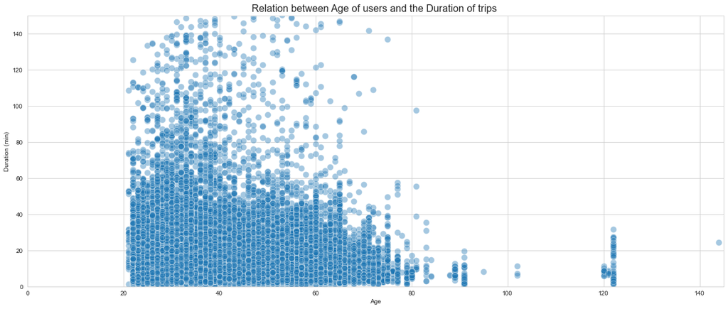

## The Most station Frequently

Now, let's look to see The Most station Frequently from the top 20 most visited stations. The most stations Frequently to start are Market St and San francisco caltrian station 2

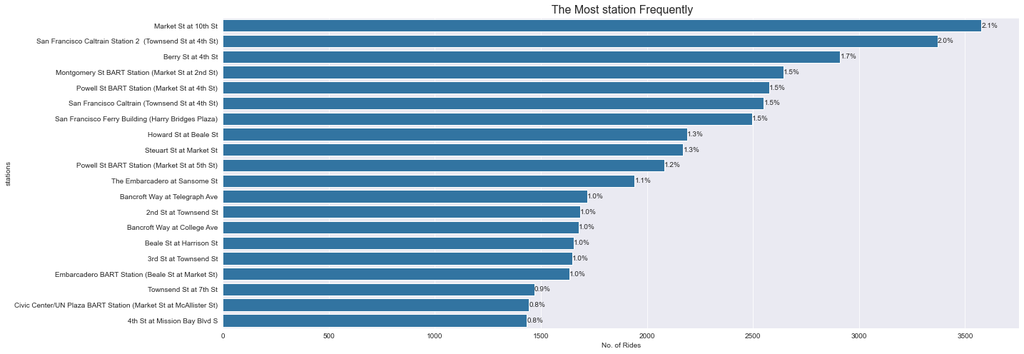

## Duration of Bike Rides from Top 10 Visited Stations

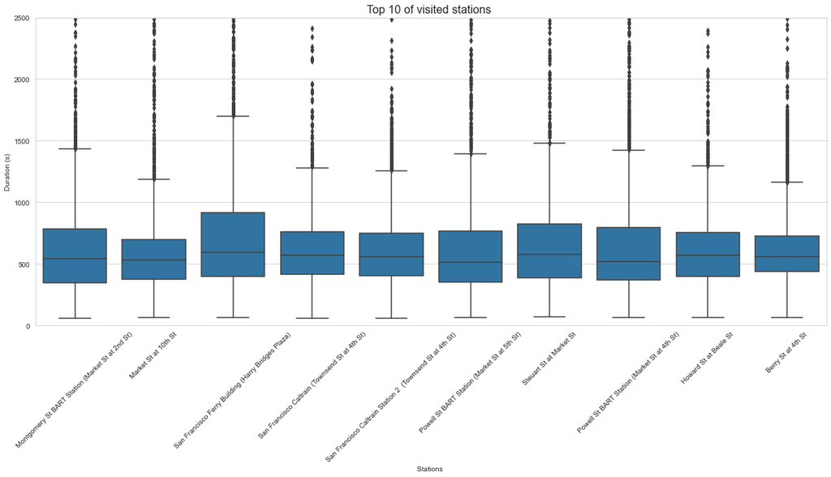

## The ages distribution effects on duration trips depending on Gender

- As we shown in two graphs we have high numbers of males at high ages more than woman.
- At higher ages for males take long trips more than woman.
- Here we observed that though the number of higher duration trip is higher for male but percentage is higher for women.

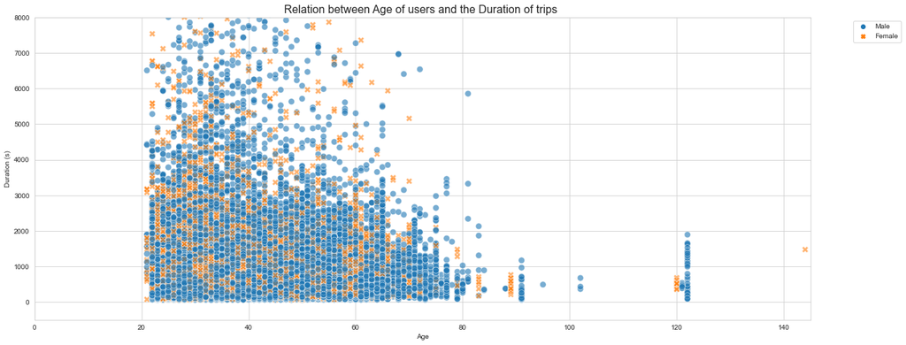

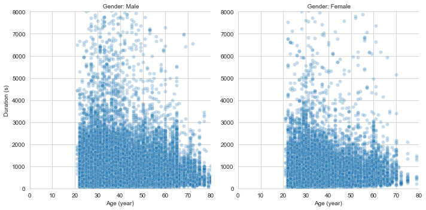

## The most trips taken in terms of time of day and day of the week

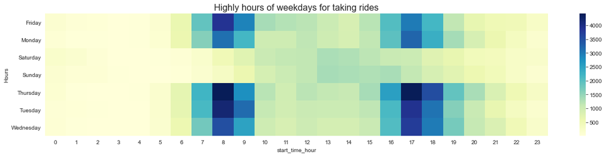

## The relation between weekday and the duration of trips in the week depending on user type

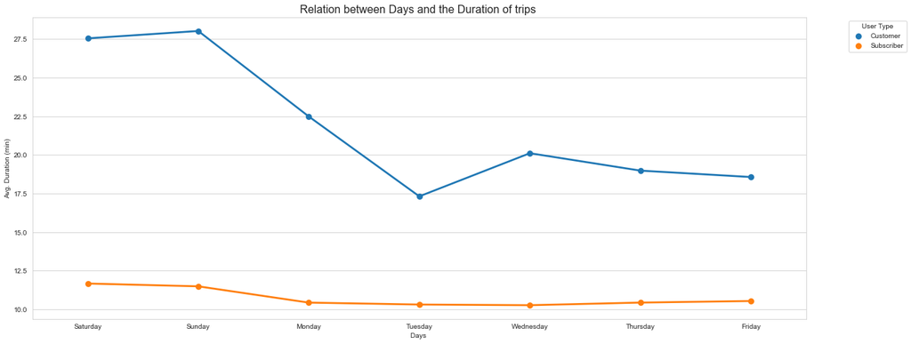

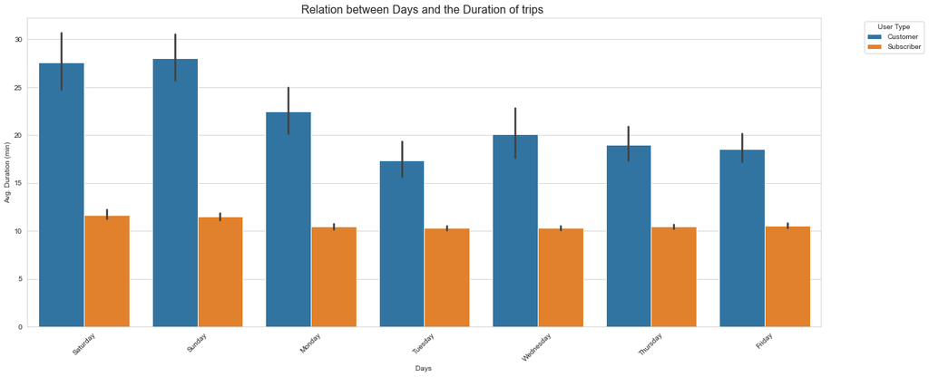

## The relation between hours of day and the duration of trips in the week depending on user type

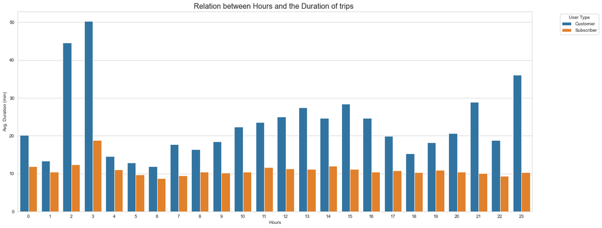

## The most trips taken in terms of time of day and day of the week depend on user type

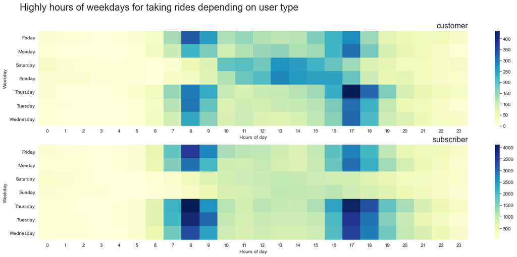

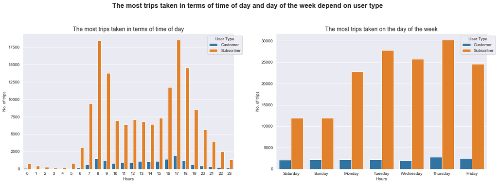